# Excersize 4

Colin Wick

5/4/2021

# Question 1

```
## # A tibble: 2 x 3
##   cluster    red  white
##   <fct>    <dbl>  <dbl>
## 1 1       0.984  0.0192
## 2 2       0.0156 0.981
```

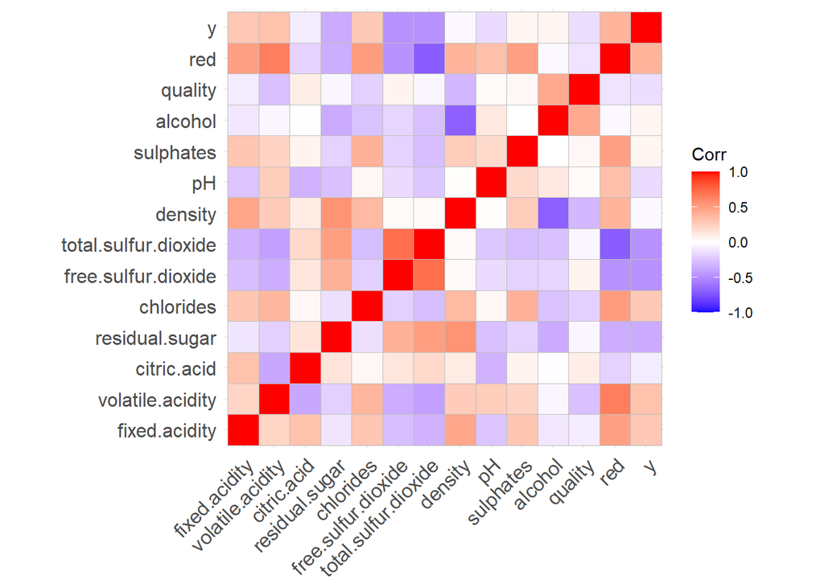

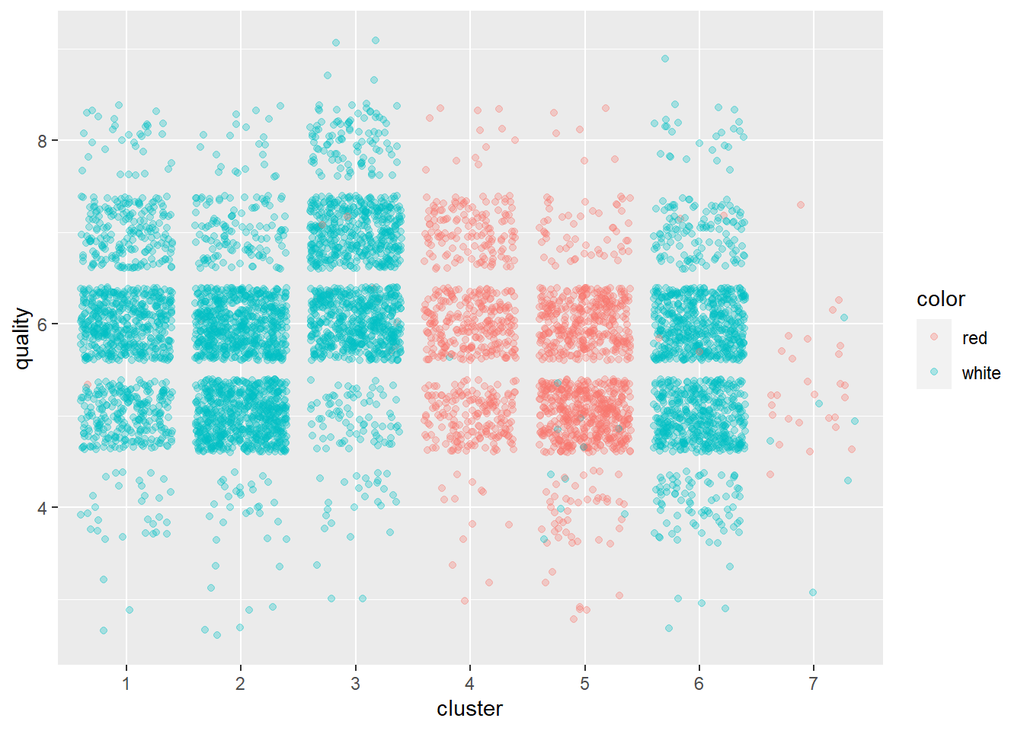

```
## Importance of first k=2 (out of 12) components:
##                           PC1    PC2
## Standard deviation     1.7440 1.6278
## Proportion of Variance 0.2535 0.2208
## Cumulative Proportion  0.2535 0.4743
```

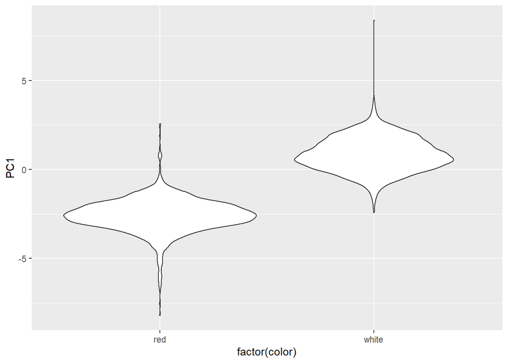

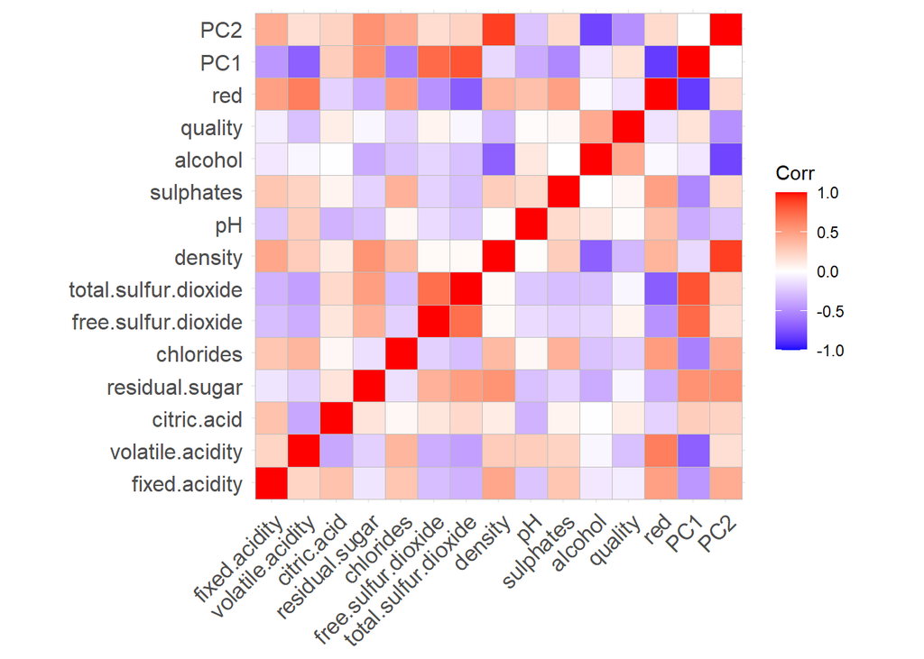

```
## Importance of first k=7 (out of 12) components:
##                           PC1    PC2    PC3    PC4     PC5     PC6    PC7
## Standard deviation     1.9518 1.5902 1.2496 0.9853 0.85077 0.78329 0.7324
## Proportion of Variance 0.3175 0.2107 0.1301 0.0809 0.06032 0.05113 0.0447
## Cumulative Proportion  0.3175 0.5282 0.6583 0.7392 0.79952 0.85065 0.8953
```

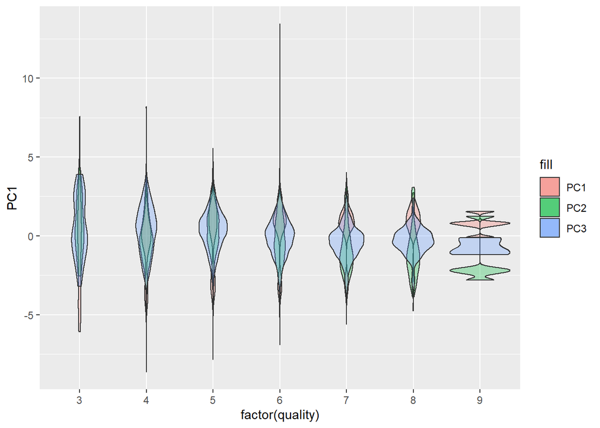

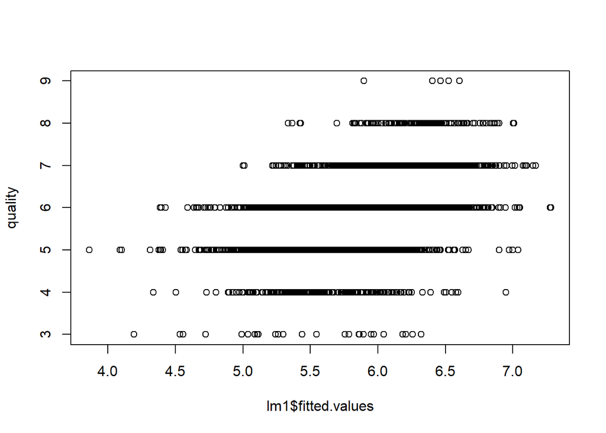

```
##
## Call:
## lm(formula = quality ~ PC1 + PC2 + PC3 + PC4 + PC5 + PC6 + PC7,
##     data = wine_pca)
##
## Residuals:
##     Min      1Q  Median      3Q     Max
## -3.3194 -0.4965 -0.0335  0.4884  3.1031
##
## Coefficients:
##              Estimate Std. Error t value Pr(>|t|)
## (Intercept)  5.818378   0.009467 614.624   <2e-16 ***
## PC1          0.058108   0.004851  11.979   <2e-16 ***
## PC2         -0.160679   0.005954 -26.989   <2e-16 ***
## PC3         -0.142682   0.007576 -18.833   <2e-16 ***
## PC4         -0.149161   0.009608 -15.524   <2e-16 ***
## PC5         -0.194415   0.011128 -17.471   <2e-16 ***
## PC6          0.152701   0.012087  12.634   <2e-16 ***
## PC7         -0.120328   0.012927  -9.308   <2e-16 ***
## ---
## Signif. codes:  0 '***' 0.001 '**' 0.01 '*' 0.05 '.' 0.1 ' ' 1
##
## Residual standard error: 0.763 on 6489 degrees of freedom
## Multiple R-squared:  0.2373, Adjusted R-squared:  0.2365
## F-statistic: 288.4 on 7 and 6489 DF,  p-value: < 2.2e-16
```

# Question 2

| Topic | Count |
| --- | --- |
| photo_sharing | 21256 |
| health_nutrition | 20235 |
| cooking | 15750 |
| politics | 14098 |
| sports_fandom | 12564 |
| travel | 12493 |
| college_uni | 12213 |
| current_events | 12030 |
| personal_fitness | 11524 |
| food | 11015 |

From here we see the beginnings of the market structure just by looking at aggregate mentions of each topic, but this is not a detailed marketing strategy.

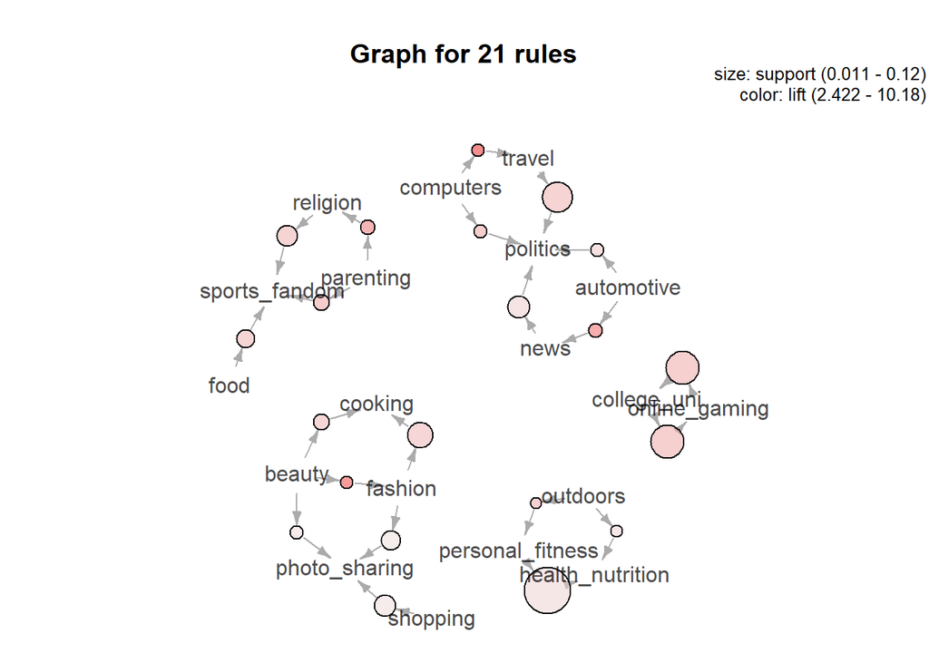

The size of each node represents the amount of times it appeared in the data, meaning a higher share of the audience consistently talked about the topic. From this we see multiple clear segments;

1. An outdoorsy, personal health and fitness type consumer, likely to be marketed to via signage and retail placement.
2. An online gaming college student consumer, likely to be marketed to on Twitch and other gaming-oriented social media sites.
3. A beauty, cooking, fashion, and photo sharing consumer, likely marketed to on Instagram.
4. Politics, news, travel, and automotive interested consumer, likely marketed to on Facebook and Twitter.
5. The food, religion, parenting consumer, who may be more difficult to reach in a measured way due to the low relative concentration on any particular digital media. Grocery stores and traditional media would be likely places to build your brand.

```
## # A tibble: 190 x 2
## # Groups:   cluster [5]
##    cluster `colSums(sm1)`
##      <int>          <dbl>
##  1       1          34671
##  2       1          12030
##  3       1          12493
##  4       1          21256
##  5       1           6408
##  6       1           8436
##  7       1          12564
##  8       1          14098
##  9       1          11015
## 10       1           6809
## # ... with 180 more rows
```

```
##          chatter   current_events           travel    photo_sharing
##            16368             6094             4664             8327
##    uncategorized          tv_film    sports_fandom         politics
##             3009             3772             4139             4251
##             food           family  home_and_garden            music
##             3527             2416             1801             2171
##             news    online_gaming         shopping health_nutrition
##             3043             2560             4415             6703
##      college_uni   sports_playing          cooking              eco
##             3643             1722             4046             1547
##        computers         business         outdoors           crafts
##             1573             1303             2143             1425
##       automotive              art         religion           beauty
##             2380             2241             2316             1413
##        parenting           dating           school personal_fitness
##             1956             1877             1793             3835
##          fashion   small_business             spam            adult
##             2036             1034               27             1676
##            Total          cluster
##           117246             4400
```

| X1 | X2 | X3 | X4 | X5 |
| --- | --- | --- | --- | --- |
| photo_sharing | college_uni | politics | health_nutrition | sports_fandom |
| health_nutrition | online_gaming | travel | cooking | religion |
| current_events | photo_sharing | news | photo_sharing | food |
| travel | sports_playing | computers | personal_fitness | parenting |
| shopping | health_nutrition | photo_sharing | fashion | school |